# Análise de latência em licitações

DGRF

15/06/2020

## Introdução e saneamento dos dados

Para isso, será utilizada a planilha de acompanhamento de termos, utilizada pela Diretoria de Gestão de Rede Física. A planilha encontra-se disponibilizada no link: https://docs.google.com/spreadsheets/u/1/d/1lx9F6m2p9iJzsB91OfwtYoiBtRBKKGk5QieuouBDXDU/edit?usp=drive_web&ouid=112067781419992811065. A análise das informações se dará por meio do software RStudio, com a utilização de bibliotecas específicas, abaixo instaladas.

```r
library(tidyverse) ## Para manipulação dos dados e gráficos.
library(lubridate) ## Para cálculos com datas.
library(DT) ## Para impressão das tabelas.
```

Para análise das informações, foi realizado o download da mesma, diretamente via GoogleDrive, e tratamento de sua estrutura. Esse procedimento foi realizado em script próprio e a base de dados foi salva como o objeto “relacao_termos.rds”. Tal objeto será lido e convertido como o item “obras”.

```r
obras <- readRDS("rdata/relacao_termos.rds")
```

Primeiramente foram constatados alguns possíveis erros e saneados dados. Primeiro, foram consideradas para análise somente as obras com datas de celebração do termo e homologação informadas. Além disso, **datas de homologação anteriores à data de celebração do respectivo termo foram descartadas**, por indicar possível erro no preenchimento da planilha.

Após esse tratamento, obtemos para análise um escopo de **4.220** obras, representando **28,24 %** do total de **14.942**.

## Informações gerais

A título de comparação, primeiro serão apresentados os dados gerais no que diz respeito à latência licitatória em dias corridos .

| Número de obras | Latência média | Latência mínima | Latência máxima | Desvio Padrão |
| --- | --- | --- | --- | --- |
| 4220 | 393 | 2 | 1992 | 346 |

**Tabela 1: Latência geral**

Lembrando que o desvio padrão ($\sigma$) é calculado da seguinte maneira $\sigma=\sqrt{\frac{1}{N-1}\sum_{i=1}^N(x_i-\bar{x})^2}$. Sendo a raiz quadrada da variância, indica a dispersão dos valores de latência ($x$) divergem em torno da média ($\bar{x}$).

## Latência por tipo de obra

A seguir apresenta-se as mesmas informações da Tabela 1, especificando pelos tipos de obra especificados na planilha:

|  | Número de obras | Latência média | Latência mínima | Latência máxima | Desvio Padrão |
| --- | --- | --- | --- | --- | --- |
| QUADRA | 91 | 529 | 39 | 1912 | 419 |
| AMPLIAÇÃO | 733 | 478 | 24 | 1941 | 348 |
| ACESSIBILIDADE | 287 | 442 | 42 | 1622 | 345 |
| REFORMA | 2061 | 391 | 2 | 1992 | 362 |
| CONSTRUÇÃO | 101 | 375 | 5 | 1500 | 320 |
| QUADRA MEC | 534 | 348 | 11 | 1606 | 321 |
| ENGENHEIRO PARA ELABORAÇÃO DE PROJETO | 413 | 249 | 9 | 1353 | 180 |

Para melhor visualização, abaixo segue gráfico com os valores de latência por tipo de obra, com destaque para a média geral.

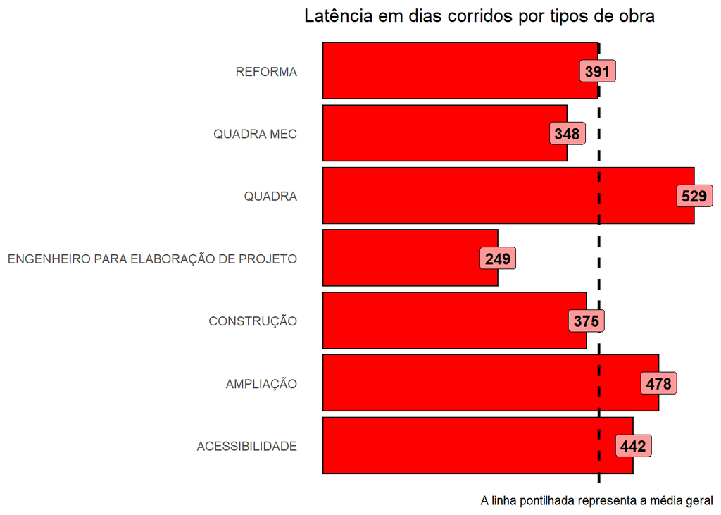